# ISyE 6414 Final Project: Predicting for Near-Earth Comets

Troy Allen, Roy Gabriel, Nattakorn Kittisut, Corey Smith & Moe Kyaw Thu

2024-06-13

# 1 Setup

## 1.1 Load Libraries

```r
# Load MASS before tidyverse so dplyr::select is not masked
library(MASS)
library(tidyverse)
library(caret)
library(glmnet)
library(stargazer)
library(car)
library(lmtest)
library(gghalfnorm)
library(faraway)
```

## 1.2 Load Data

```r
comet_data <- read.csv("Near-Earth_Comets_-_Orbital_Elements_20240605.csv")
head(comet_data)
```

```
##                          Object Epoch..TDB. TP..TDB.         e    i..deg.
## 1          P/2004 R1 (McNaught)       54629  2455249 0.6825269   4.894556
## 2 P/2008 S1 (Catalina-McNaught)       55101  2454741 0.6663128  15.100746
## 3                     1P/Halley       49400  2446467 0.9671429 162.262691
## 4                      2P/Encke       56870  2456618 0.8482683  11.779995
## 5                      3D/Biela       -9480  2390514 0.7512990  13.216400
## 6                    5D/Brorsen        7440  2407440 0.8097960  29.382100
##       w..deg. Node..deg.    q..AU. Q..AU. P..yr. MOID..AU. A1..AU.d.2.
## 1   0.6268378  295.98545 0.9861920   5.23   5.48  0.027011          NA
## 2 203.6490232  111.39200 1.1906416   5.95   6.74  0.194101          NA
## 3 111.3324851   58.42008 0.5859781  35.08  75.32  0.063782    2.70e-10
## 4 186.5403463  334.56981 0.3360924   4.09   3.30  0.173092    1.58e-10
## 5 221.6588000  250.66900 0.8790730   6.19   6.65  0.000518    3.90e-09
## 6  14.9468000  102.96760 0.5898470   5.61   5.46  0.366559    1.27e-08
##   A2..AU.d.2. A3..AU.d.2. DT..d.      ref                   Object_name
## 1          NA          NA     NA       20          P/2004 R1 (McNaught)
## 2          NA          NA     NA       13 P/2008 S1 (Catalina-McNaught)
## 3    1.55e-10          NA     NA  J863/77                     1P/Halley
## 4   -5.05e-12          NA     NA       74                      2P/Encke
## 5   -2.54e-10          NA     NA IAUCAT03                      3D/Biela
## 6    1.34e-09          NA     NA IAUCAT03                    5D/Brorsen
```

# 2 Data Cleaning

## 2.1 Missing Values

```r
missing_values <- comet_data %>%
  summarise(across(everything(), ~ sum(is.na(.)))) %>%
  pivot_longer(everything(), names_to = "Column", values_to = "MissingValues") %>%
  filter(MissingValues > 0)

missing_values
```

```
## # A tibble: 4 × 2
##   Column      MissingValues
##   <chr>               <int>
## 1 A1..AU.d.2.           122
## 2 A2..AU.d.2.           119
## 3 A3..AU.d.2.           150
## 4 DT..d.                156
```

The columns with missing values are:

- **A1**: 122 missing values
- **A2**: 119 missing values
- **A3**: 150 missing values
- **DT**: 156 missing values

Given the high proportion of missing values, dropping these columns is preferable to dropping rows.

```r
comet_data[, c("A1..AU.d.2.", "A2..AU.d.2.", "A3..AU.d.2.", "DT..d.")] %>%
  head(10)
```

```
##    A1..AU.d.2. A2..AU.d.2. A3..AU.d.2. DT..d.
## 1           NA          NA          NA     NA
## 2           NA          NA          NA     NA
## 3     2.70e-10    1.55e-10          NA     NA
## 4     1.58e-10   -5.05e-12          NA     NA
## 5     3.90e-09   -2.54e-10          NA     NA
## 6     1.27e-08    1.34e-09          NA     NA
## 7     7.86e-11   -1.15e-11   -1.53e-10    131
## 8     6.89e-10    1.37e-10   -4.59e-10     NA
## 9    -1.02e-09   -2.71e-10          NA     NA
## 10    9.45e-09    6.49e-10          NA     NA
```

## 2.2 Drop Columns with Excessive Missing Data

We drop A1, A2, A3, and DT due to the high number of missing values.

```r
comet_data_clean <- comet_data %>%
  select(-c("A1..AU.d.2.", "A2..AU.d.2.", "A3..AU.d.2.", "DT..d."))

head(comet_data_clean)
```

```
##                          Object Epoch..TDB. TP..TDB.         e    i..deg.
## 1          P/2004 R1 (McNaught)       54629  2455249 0.6825269   4.894556
## 2 P/2008 S1 (Catalina-McNaught)       55101  2454741 0.6663128  15.100746
## 3                     1P/Halley       49400  2446467 0.9671429 162.262691
## 4                      2P/Encke       56870  2456618 0.8482683  11.779995
## 5                      3D/Biela       -9480  2390514 0.7512990  13.216400
## 6                    5D/Brorsen        7440  2407440 0.8097960  29.382100
##       w..deg. Node..deg.    q..AU. Q..AU. P..yr. MOID..AU.      ref
## 1   0.6268378  295.98545 0.9861920   5.23   5.48  0.027011       20
## 2 203.6490232  111.39200 1.1906416   5.95   6.74  0.194101       13
## 3 111.3324851   58.42008 0.5859781  35.08  75.32  0.063782  J863/77
## 4 186.5403463  334.56981 0.3360924   4.09   3.30  0.173092       74
## 5 221.6588000  250.66900 0.8790730   6.19   6.65  0.000518 IAUCAT03
## 6  14.9468000  102.96760 0.5898470   5.61   5.46  0.366559 IAUCAT03
##                     Object_name
## 1          P/2004 R1 (McNaught)
## 2 P/2008 S1 (Catalina-McNaught)
## 3                     1P/Halley
## 4                      2P/Encke
## 5                      3D/Biela
## 6                    5D/Brorsen
```

## 2.3 Outlier Detection

Using Z-scores with a threshold of 2 to identify outliers across numeric columns.

```r
numeric_cols <- select_if(comet_data_clean, is.numeric)
z_scores <- numeric_cols %>% mutate(across(everything(), scale))

threshold <- 2

outliers <- comet_data_clean %>%
  filter(rowSums(abs(z_scores) > threshold, na.rm = TRUE) > 0)

cat("Number of outlier rows:", nrow(outliers), "\n")
```

```
## Number of outlier rows: 44
```

```r
outlier_columns <- apply(abs(z_scores) > threshold, 1, function(x) colnames(comet_data_clean)[x])

for (i in 1:nrow(outliers)) {
  if (length(outlier_columns[[i]]) > 0) {
    cat("Row:", i, "\n")
    cat("Outlier columns:", paste(outlier_columns[i], collapse = ", "), "\n")
    print(outliers[i, ])
    cat("\n")
  }
}
```

```
## Row: 1
## Outlier columns: i..deg.
##                 Object Epoch..TDB. TP..TDB.         e  i..deg.   w..deg.
## 1 P/2004 R1 (McNaught)       54629  2455249 0.6825269 4.894556 0.6268378
##   Node..deg.   q..AU. Q..AU. P..yr. MOID..AU. ref          Object_name
## 1   295.9854 0.986192   5.23   5.48  0.027011  20 P/2004 R1 (McNaught)
##
## Row: 3
## Outlier columns: c("e", "q..AU.", "Q..AU.")
##     Object Epoch..TDB. TP..TDB.         e i..deg.  w..deg. Node..deg.    q..AU.
## 3 2P/Encke       56870  2456618 0.8482683   11.78 186.5403   334.5698 0.3360924
##   Q..AU. P..yr. MOID..AU. ref Object_name
## 3   4.09    3.3  0.173092  74    2P/Encke
##
## Row: 4
## Outlier columns: c("w..deg.", "Node..deg.")
##     Object Epoch..TDB. TP..TDB.        e i..deg.  w..deg. Node..deg.   q..AU.
## 4 3D/Biela       -9480  2390514 0.751299 13.2164 221.6588    250.669 0.879073
##   Q..AU. P..yr. MOID..AU.      ref Object_name
## 4   6.19   6.65  0.000518 IAUCAT03    3D/Biela
##
## Row: 5
## Outlier columns: c("Object", "Epoch..TDB.", "MOID..AU.", "ref")
##       Object Epoch..TDB. TP..TDB.        e i..deg. w..deg. Node..deg.   q..AU.
## 5 5D/Brorsen        7440  2407440 0.809796 29.3821 14.9468   102.9676 0.589847
##   Q..AU. P..yr. MOID..AU.      ref Object_name
## 5   5.61   5.46  0.366559 IAUCAT03  5D/Brorsen
##
## Row: 6
## Outlier columns: c("Object", "Epoch..TDB.", "P..yr.", "MOID..AU.", "ref")
##            Object Epoch..TDB. TP..TDB.         e  i..deg.  w..deg. Node..deg.
## 6 12P/Pons-Brooks       35000  2434885 0.9548124 74.17689 199.0285   255.8911
##      q..AU. Q..AU. P..yr. MOID..AU. ref     Object_name
## 6 0.7736671  33.47  70.85    0.1873  15 12P/Pons-Brooks
##
## Row: 9
## Outlier columns: c("Object", "Epoch..TDB.", "q..AU.", "MOID..AU.", "ref")
##                Object Epoch..TDB. TP..TDB.         e  i..deg.  w..deg.
## 9 23P/Brorsen-Metcalf       47800  2447781 0.9719523 19.33394 129.6107
##   Node..deg.    q..AU. Q..AU. P..yr. MOID..AU. ref         Object_name
```

[output cut: 28 more lines]

```
## 21 1.297735    5.1   5.73  0.393614  27 294P/LINEAR
##
## Row: 22
## Outlier columns: e
##         Object Epoch..TDB. TP..TDB.         e  i..deg.   w..deg. Node..deg.
## 22 306P/LINEAR       53391  2452865 0.5982595 8.364458 0.7688016   341.4986
##      q..AU. Q..AU. P..yr. MOID..AU. ref Object_name
## 22 1.246919   4.96   5.47  0.239208  31 306P/LINEAR
##
## Row: 23
## Outlier columns: P..yr.
##                Object Epoch..TDB. TP..TDB.         e  i..deg.  w..deg.
## 23 C/1906 V1 (Thiele)       17544  2417536 0.9487614 56.03318 8.456068
##    Node..deg.   q..AU. Q..AU. P..yr. MOID..AU. ref        Object_name
## 23   85.80951 1.208611  45.97 114.56  0.230296   3 C/1906 V1 (Thiele)
```

## 2.4 Summary Statistics

```r
numeric_data <- comet_data_clean[, sapply(comet_data_clean, is.numeric)]

summary_stats <- data.frame(
  Mean = colMeans(numeric_data, na.rm = TRUE),
  SD = sapply(numeric_data, sd, na.rm = TRUE)
)

round(summary_stats, 4)
```

```
##                     Mean        SD
## Epoch..TDB.   52547.8250 8225.4599
## TP..TDB.    2452494.5370 8241.2780
## e                 0.7489    0.1107
## i..deg.          24.5620   33.9881
## w..deg.         176.6939   87.7931
## Node..deg.      127.0524   97.4613
## q..AU.            0.9173    0.2777
## Q..AU.            9.4866   10.8171
## P..yr.           15.5251   29.0399
## MOID..AU.         0.1198    0.1198
```

## 2.5 Standardization

Creating a standardized version of the numeric data for potential use in modeling.

```r
standardized_comet_data <- scale(numeric_data)
head(standardized_comet_data)
```

```
##      Epoch..TDB.   TP..TDB.          e    i..deg.    w..deg. Node..deg.
## [1,]   0.2530162  0.3341728 -0.5992880 -0.5786555 -2.0054760  1.7333345
## [2,]   0.3103991  0.2726266 -0.7457170 -0.2783685  0.3070305 -0.1606837
## [3,]  -0.3826929 -0.7313358  1.9710607  4.0514357 -0.7444929 -0.7042013
## [4,]   0.5254630  0.5003674  0.8975112 -0.3760718  0.1121556  2.1292286
## [5,]  -7.5409552 -7.5207294  0.0217881 -0.3338099  0.5121693  1.2683657
## [6,]  -5.4839274 -5.4669922  0.5500708  0.1418180 -1.8423657 -0.2471222
##          q..AU.     Q..AU.     P..yr.  MOID..AU.
## [1,]  0.2481931 -0.3935104 -0.3459081 -0.7742064
## [2,]  0.9844537 -0.3269489 -0.3025195  0.6204674
## [3,] -1.1930512  2.3660198  2.0590619 -0.4672847
## [4,] -2.0929359 -0.4988995 -0.4209774  0.4451086
## [5,] -0.1375623 -0.3047617 -0.3056187 -0.9953393
## [6,] -1.1791186 -0.3583807 -0.3465969  2.0599470
```

# 3 Exploratory Data Analysis

## 3.1 Eccentricity vs. Inclination

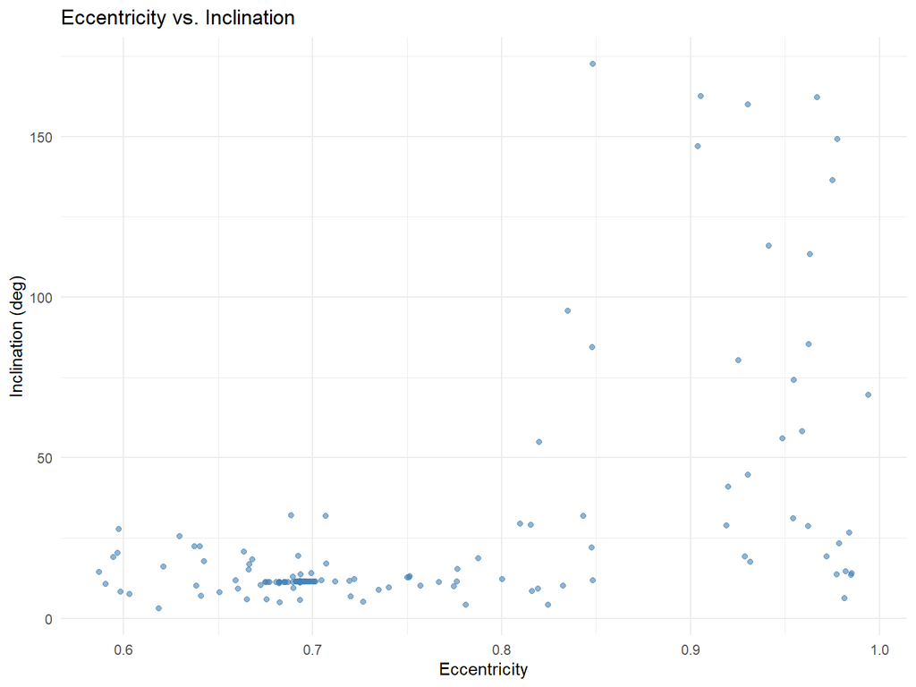

```r
ggplot(comet_data_clean, aes(x = e, y = i..deg.)) +
  geom_point(alpha = 0.6, color = "steelblue") +
  labs(
    x = "Eccentricity",
    y = "Inclination (deg)",
    title = "Eccentricity vs. Inclination"
  ) +
  theme_minimal()
```

## 3.2 Eccentricity vs. Perihelion Distance

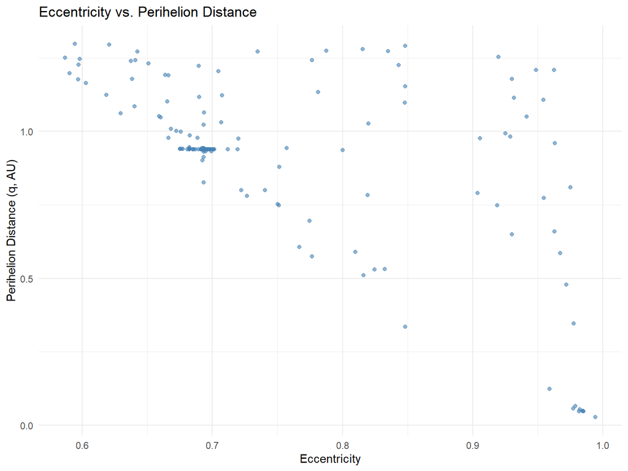

```r
ggplot(comet_data_clean, aes(x = e, y = q..AU.)) +
  geom_point(alpha = 0.6, color = "steelblue") +
  labs(
    x = "Eccentricity",
    y = "Perihelion Distance (q, AU)",
    title = "Eccentricity vs. Perihelion Distance"
  ) +
  theme_minimal()
```

## 3.3 Scatterplot Matrix of Orbital Elements

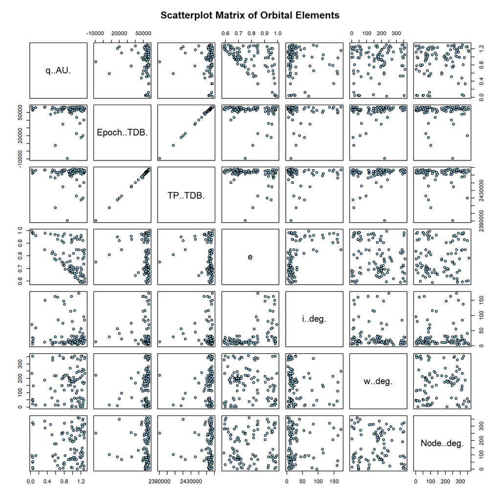

```r
orbital_elements <- comet_data[, c("q..AU.", "Epoch..TDB.", "TP..TDB.", "e",
                                    "i..deg.", "w..deg.", "Node..deg.")]

pairs(orbital_elements, pch = 21, bg = "skyblue",
      main = "Scatterplot Matrix of Orbital Elements")
```

# 4 Research Question 1: Which Orbital Elements Best Predict MOID?

> **RQ1:** Which orbital elements best predict the minimum distance between the comet and Earth (MOID)? Are all input parameters significant? Is MOID impacted more by orbit eccentricity (e) or its critical angles (i, w, Node)?

## 4.1 Full Linear Model

```r
orbit <- read.csv("comet_data_cleaned.csv")
sub.orbit <- orbit[, 2:11]
```

```r
rq1.lm <- lm(MOID..AU. ~ ., data = sub.orbit)
summary(rq1.lm)
```

```
##
## Call:
## lm(formula = MOID..AU. ~ ., data = sub.orbit)
##
## Residuals:
##      Min       1Q   Median       3Q      Max
## -0.27067 -0.03660 -0.02732  0.04212  0.44401
##
## Coefficients:
##               Estimate Std. Error t value Pr(>|t|)
## (Intercept) -9.504e+00  5.343e+01  -0.178 0.859054
## Epoch..TDB. -4.182e-06  2.233e-05  -0.187 0.851726
## TP..TDB.     3.654e-06  2.228e-05   0.164 0.869960
## e            8.631e-01  2.321e-01   3.718 0.000283 ***
## i..deg.      1.364e-06  3.300e-04   0.004 0.996708
## w..deg.     -1.943e-04  9.299e-05  -2.090 0.038325 *
## Node..deg.   1.894e-04  8.410e-05   2.253 0.025735 *
## q..AU.       2.819e-01  6.273e-02   4.494 1.39e-05 ***
## Q..AU.       2.222e-03  8.748e-03   0.254 0.799856
## P..yr.      -2.093e-03  2.744e-03  -0.763 0.446828
## ---
## Signif. codes:  0 '***' 0.001 '**' 0.01 '*' 0.05 '.' 0.1 ' ' 1
##
## Residual standard error: 0.09654 on 150 degrees of freedom
## Multiple R-squared:  0.3875, Adjusted R-squared:  0.3507
## F-statistic: 10.54 on 9 and 150 DF,  p-value: 1.471e-12
```

**Interpretation:** The significant predictors are `q.AU`, `Node.deg`, `w.deg`, and `e`.

## 4.2 Model Diagnostics (Full Model)

```r
# Normality
shapiro.test(resid(rq1.lm))
```

```
##
##  Shapiro-Wilk normality test
##
## data:  resid(rq1.lm)
## W = 0.89569, p-value = 3.234e-09
```

There is strong evidence that the residuals are **not normally distributed**.

```r
# Multicollinearity
vif(rq1.lm)
```

```
## Epoch..TDB.    TP..TDB.           e     i..deg.     w..deg.  Node..deg.
##  575.732499  575.160715   11.270028    2.146876    1.137160    1.146094
##      q..AU.      Q..AU.      P..yr.
##    5.176505  152.786828  108.347699
```

High VIF values for `Epoch.TDB`, `TP.TDB`, `Q.AU`, and `P.yr` indicate **multicollinearity**.

```r
# Heteroskedasticity
ncvTest(rq1.lm)
```

```
## Non-constant Variance Score Test
## Variance formula: ~ fitted.values
## Chisquare = 21.54705, Df = 1, p = 3.4525e-06
```

With p-value < 0.05, there is **heteroskedasticity** in the model.

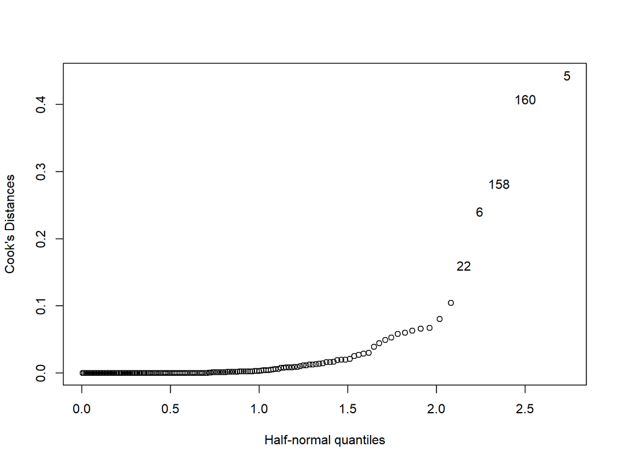

```r
# Influential observations
cook.rq.1 <- cooks.distance(rq1.lm)
halfnorm(cook.rq.1, 5, ylab = "Cook's Distances")
```

Outliers identified at observations: **5, 158, 6, 22, and 160**.

## 4.3 Diagnostic Summary Table

```r
shapiro_w <- 0.89569
shapiro_p <- 3.234e-09

vif_values <- c(
  Epoch_TDB = 575.73, TP_TDB = 575.16, e = 11.27, i_deg = 2.15,
  w_deg = 1.14, Node_deg = 1.15, q_AU = 5.18, Q_AU = 152.79, P_yr = 108.35
)

ncv_chisquare <- 21.55
ncv_p <- 3.45e-06

result_table <- data.frame(
  Test = c(
    "Shapiro-Wilk Normality",
    rep("Variance Inflation Factor", length(vif_values)),
    "Non-constant Variance",
    "Cook's Distance Outliers"
  ),
  Result = c(
    paste("W:", shapiro_w, ", p-value:", format(shapiro_p, scientific = TRUE)),
    paste(names(vif_values), ":", round(vif_values, 2)),
    paste("Chi-sq:", ncv_chisquare, ", p:", format(ncv_p, scientific = TRUE)),
    "Observations: 5, 158, 6, 22, 160"
  )
)

stargazer(result_table, type = "text", summary = FALSE, rownames = FALSE)
```

```
##
## ==========================================================
## Test                                   Result
## ----------------------------------------------------------
## Shapiro-Wilk Normality    W: 0.89569 , p-value: 3.234e-09
## Variance Inflation Factor        Epoch_TDB : 575.73
## Variance Inflation Factor         TP_TDB : 575.16
## Variance Inflation Factor            e : 11.27
## Variance Inflation Factor           i_deg : 2.15
## Variance Inflation Factor           w_deg : 1.14
## Variance Inflation Factor         Node_deg : 1.15
## Variance Inflation Factor           q_AU : 5.18
## Variance Inflation Factor          Q_AU : 152.79
## Variance Inflation Factor          P_yr : 108.35
## Non-constant Variance       Chi-sq: 21.55 , p: 3.45e-06
## Cook's Distance Outliers  Observations: 5, 158, 6, 22, 160
## ----------------------------------------------------------
```

## 4.4 Forward Stepwise Regression

```r
simple_model <- lm(MOID..AU. ~ 1, data = sub.orbit)
full_model <- lm(MOID..AU. ~ ., data = sub.orbit)

rq1_forward <- step(simple_model,
  scope = list(lower = simple_model, upper = full_model),
  direction = "forward", trace = 0
)

summary(rq1_forward)
```

```
##
## Call:
## lm(formula = MOID..AU. ~ Q..AU. + P..yr. + q..AU. + e + Node..deg. +
##     w..deg., data = sub.orbit)
##
## Residuals:
##      Min       1Q   Median       3Q      Max
## -0.27247 -0.03634 -0.02693  0.04147  0.44390
##
## Coefficients:
##               Estimate Std. Error t value Pr(>|t|)
## (Intercept) -7.803e-01  1.861e-01  -4.194 4.63e-05 ***
## Q..AU.       2.184e-03  7.970e-03   0.274 0.784439
## P..yr.      -2.106e-03  2.524e-03  -0.835 0.405300
## q..AU.       2.885e-01  5.907e-02   4.884 2.60e-06 ***
## e            8.802e-01  2.260e-01   3.895 0.000146 ***
## Node..deg.   1.883e-04  8.324e-05   2.262 0.025106 *
## w..deg.     -2.020e-04  9.098e-05  -2.221 0.027852 *
## ---
## Signif. codes:  0 '***' 0.001 '**' 0.01 '*' 0.05 '.' 0.1 ' ' 1
##
## Residual standard error: 0.09569 on 153 degrees of freedom
## Multiple R-squared:  0.3862, Adjusted R-squared:  0.3621
## F-statistic: 16.04 on 6 and 153 DF,  p-value: 2.885e-14
```

Selected variables: `Q.AU`, `P.yr`, `q.AU`, `e`, `Node.deg`, and `w.deg` (lowest AIC: -744.09).

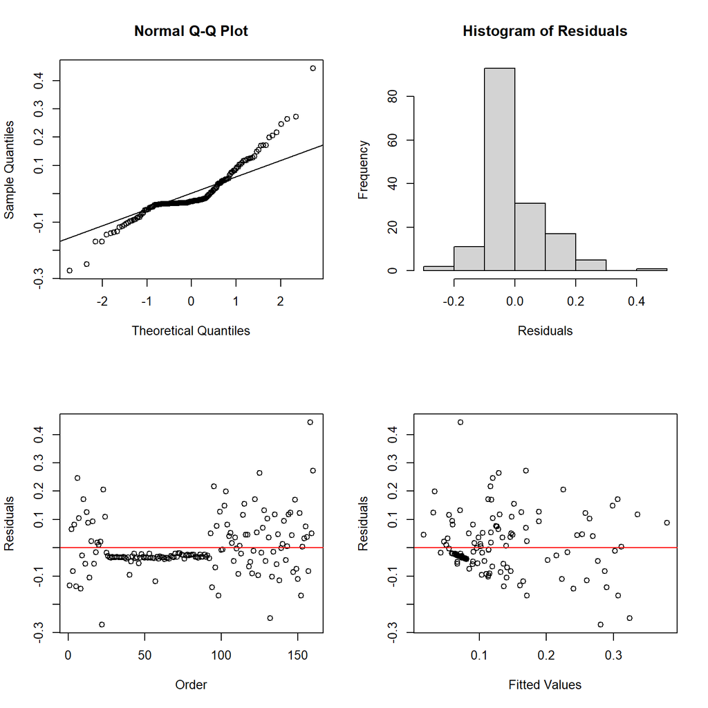

```r
par(mfrow = c(2, 2))
qqnorm(residuals(rq1_forward)); qqline(residuals(rq1_forward))
hist(residuals(rq1_forward), main = "Histogram of Residuals", xlab = "Residuals")
plot(residuals(rq1_forward), xlab = "Order", ylab = "Residuals")
abline(0, 0, lty = 1, col = "red")
plot(fitted(rq1_forward), residuals(rq1_forward), xlab = "Fitted Values", ylab = "Residuals")
abline(0, 0, lty = 1, col = "red")
```

## 4.5 Backward Stepwise Regression

```r
rq1_backward <- step(full_model,
  scope = list(lower = simple_model, upper = full_model),
  direction = "backward", trace = 0
)

summary(rq1_backward)
```

```
##
## Call:
## lm(formula = MOID..AU. ~ e + w..deg. + Node..deg. + q..AU. +
##     P..yr., data = sub.orbit)
##
## Residuals:
##      Min       1Q   Median       3Q      Max
## -0.27062 -0.03631 -0.02642  0.04022  0.44568
##
## Coefficients:
##               Estimate Std. Error t value Pr(>|t|)
## (Intercept) -8.164e-01  1.310e-01  -6.230 4.25e-09 ***
## e            9.295e-01  1.365e-01   6.811 2.05e-10 ***
## w..deg.     -2.061e-04  8.950e-05  -2.303 0.022638 *
## Node..deg.   1.882e-04  8.299e-05   2.268 0.024697 *
## q..AU.       2.995e-01  4.337e-02   6.905 1.24e-10 ***
## P..yr.      -1.424e-03  4.193e-04  -3.397 0.000867 ***
## ---
## Signif. codes:  0 '***' 0.001 '**' 0.01 '*' 0.05 '.' 0.1 ' ' 1
##
## Residual standard error: 0.0954 on 154 degrees of freedom
## Multiple R-squared:  0.3859, Adjusted R-squared:  0.3659
## F-statistic: 19.35 on 5 and 154 DF,  p-value: 6.391e-15
```

Selected variables: `e`, `w.deg`, `Node.deg`, `q.AU`, and `P.yr` (lowest AIC: -746.01).

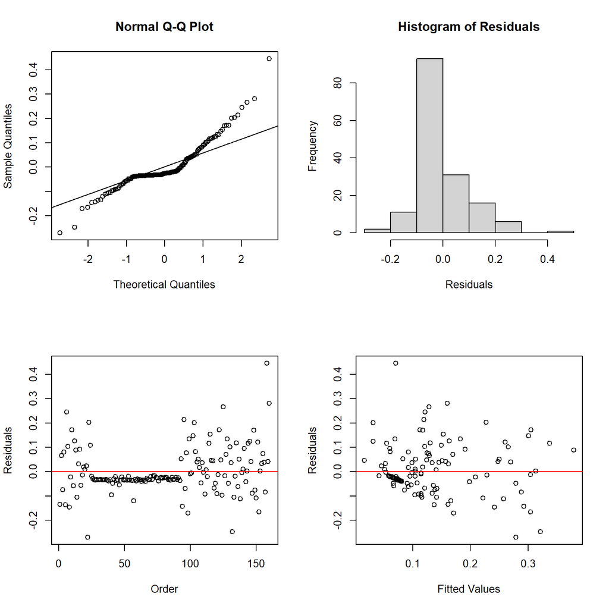

```r
par(mfrow = c(2, 2))
qqnorm(residuals(rq1_backward)); qqline(residuals(rq1_backward))
hist(residuals(rq1_backward), main = "Histogram of Residuals", xlab = "Residuals")
plot(residuals(rq1_backward), xlab = "Order", ylab = "Residuals")
abline(0, 0, lty = 1, col = "red")
plot(fitted(rq1_backward), residuals(rq1_backward), xlab = "Fitted Values", ylab = "Residuals")
abline(0, 0, lty = 1, col = "red")
```

## 4.6 Lasso Regression

```r
X <- model.matrix(MOID..AU. ~ ., data = sub.orbit)[, -1]
y <- sub.orbit$MOID..AU.

cv_model <- cv.glmnet(X, y, alpha = 1)
best_lambda <- cv_model$lambda.min
cat("Best lambda:", best_lambda, "\n")
```

```
## Best lambda: 0.0021124
```

```r
best_lasso <- glmnet(X, y, alpha = 1, lambda = best_lambda)
coefficients <- as.matrix(coef(best_lasso))
print(coefficients)
```

```
##                        s0
## (Intercept) -6.254610e-01
## Epoch..TDB. -4.993249e-07
## TP..TDB.     0.000000e+00
## e            7.566544e-01
## i..deg.      1.796617e-06
## w..deg.     -1.750363e-04
## Node..deg.   1.795383e-04
## q..AU.       2.477049e-01
## Q..AU.       0.000000e+00
## P..yr.      -9.225876e-04
```

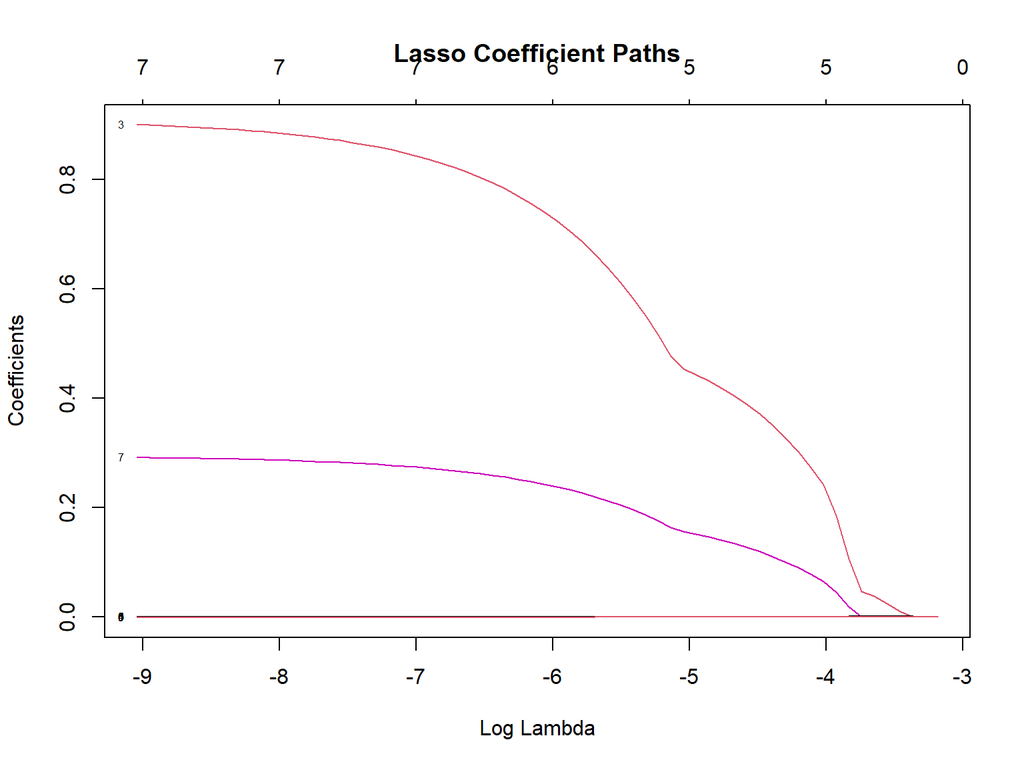

```r
base_lasso <- glmnet(X, y, alpha = 1)
plot(base_lasso, xvar = "lambda", label = TRUE)
title("Lasso Coefficient Paths")
```

```r
threshold <- 1e-6
selected_vars <- rownames(coefficients)[abs(coefficients) > threshold]
selected_vars <- selected_vars[selected_vars != "(Intercept)"]

cat("Selected variables by Lasso:\n")
```

```
## Selected variables by Lasso:
```

```r
print(selected_vars)
```

```
## [1] "e"          "i..deg."    "w..deg."    "Node..deg." "q..AU."
## [6] "P..yr."
```

## 4.7 Lasso-Selected Model

```r
rq1_lasso_model <- lm(MOID..AU. ~ e + i..deg. + w..deg. + Node..deg. + q..AU. + P..yr.,
  data = sub.orbit
)

summary(rq1_lasso_model)
```

```
##
## Call:
## lm(formula = MOID..AU. ~ e + i..deg. + w..deg. + Node..deg. +
##     q..AU. + P..yr., data = sub.orbit)
##
## Residuals:
##      Min       1Q   Median       3Q      Max
## -0.27033 -0.03631 -0.02642  0.04005  0.44576
##
## Coefficients:
##               Estimate Std. Error t value Pr(>|t|)
## (Intercept) -8.168e-01  1.388e-01  -5.884 2.44e-08 ***
## e            9.300e-01  1.487e-01   6.253 3.83e-09 ***
## i..deg.     -2.813e-06  2.931e-04  -0.010 0.992356
## w..deg.     -2.062e-04  9.009e-05  -2.288 0.023483 *
## Node..deg.   1.882e-04  8.332e-05   2.259 0.025294 *
## q..AU.       2.996e-01  4.468e-02   6.705 3.66e-10 ***
## P..yr.      -1.424e-03  4.229e-04  -3.367 0.000962 ***
## ---
## Signif. codes:  0 '***' 0.001 '**' 0.01 '*' 0.05 '.' 0.1 ' ' 1
##
## Residual standard error: 0.09571 on 153 degrees of freedom
## Multiple R-squared:  0.3859, Adjusted R-squared:  0.3618
## F-statistic: 16.02 on 6 and 153 DF,  p-value: 2.991e-14
```

All variables except `i.deg` are significant predictors for MOID.

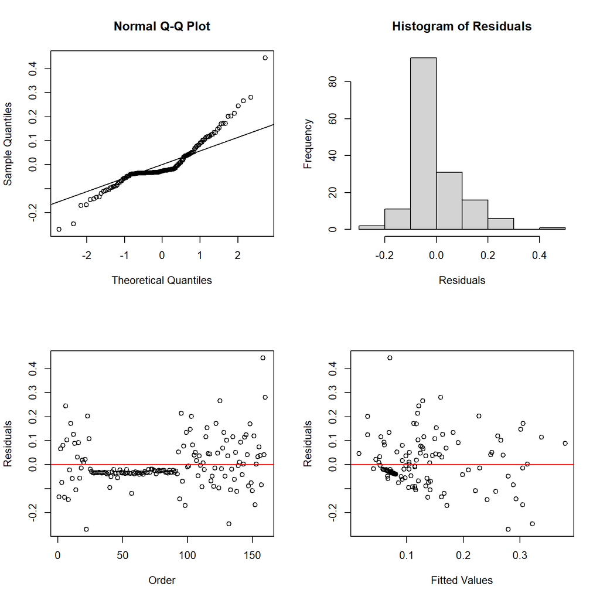

```r
par(mfrow = c(2, 2))
qqnorm(residuals(rq1_lasso_model)); qqline(residuals(rq1_lasso_model))
hist(residuals(rq1_lasso_model), main = "Histogram of Residuals", xlab = "Residuals")
plot(residuals(rq1_lasso_model), xlab = "Order", ylab = "Residuals")
abline(0, 0, lty = 1, col = "red")
plot(fitted(rq1_lasso_model), residuals(rq1_lasso_model), xlab = "Fitted Values", ylab = "Residuals")
abline(0, 0, lty = 1, col = "red")
```

# 5 Research Question 2: Impact of Perihelion & Aphelion on Orbital Period

> **RQ2:** Do the minimum (q) and maximum (Q) distances between the comet and the Sun have an impact on the orbital period (P)? Are these values correlated or dependent on other orbital elements?

## 5.1 Initial Model with Interaction Term

```r
rq2.lm <- lm(P..yr. ~ q..AU. + Q..AU. + I(q..AU. * Q..AU.), data = sub.orbit)
summary(rq2.lm)
```

```
##
## Call:
## lm(formula = P..yr. ~ q..AU. + Q..AU. + I(q..AU. * Q..AU.), data = sub.orbit)
##
## Residuals:
##     Min      1Q  Median      3Q     Max
## -11.044  -0.168   1.160   1.383  28.259
##
## Coefficients:
##                    Estimate Std. Error t value Pr(>|t|)
## (Intercept)         -7.5902     1.6596  -4.573 9.72e-06 ***
## q..AU.              -2.1177     1.7256  -1.227  0.22157
## Q..AU.               2.2726     0.1280  17.757  < 2e-16 ***
## I(q..AU. * Q..AU.)   0.3960     0.1294   3.060  0.00261 **
## ---
## Signif. codes:  0 '***' 0.001 '**' 0.01 '*' 0.05 '.' 0.1 ' ' 1
##
## Residual standard error: 4.245 on 156 degrees of freedom
## Multiple R-squared:  0.979,  Adjusted R-squared:  0.9786
## F-statistic:  2429 on 3 and 156 DF,  p-value: < 2.2e-16
```

The maximum distance (Q) and the q*Q interaction significantly impact orbital period, while minimum distance (q) alone does not.

## 5.2 Correlation Analysis

```r
cat("Correlation between q and Q:", cor(sub.orbit$q..AU., sub.orbit$Q..AU.), "\n")
```

```
## Correlation between q and Q: 0.04436844
```

Weak positive correlation (r = 0.044) between perihelion and aphelion distances.

```r
round(cor(sub.orbit), 2)
```

```
##             Epoch..TDB. TP..TDB.     e i..deg. w..deg. Node..deg. q..AU. Q..AU.
## Epoch..TDB.        1.00     1.00 -0.20   -0.07    0.20      -0.08  -0.04  -0.21
## TP..TDB.           1.00     1.00 -0.21   -0.08    0.21      -0.08  -0.03  -0.22
## e                 -0.20    -0.21  1.00    0.57   -0.26       0.21  -0.57   0.67
## i..deg.           -0.07    -0.08  0.57    1.00   -0.22       0.18  -0.09   0.60
## w..deg.            0.20     0.21 -0.26   -0.22    1.00      -0.10   0.13  -0.23
## Node..deg.        -0.08    -0.08  0.21    0.18   -0.10       1.00   0.11   0.31
## q..AU.            -0.04    -0.03 -0.57   -0.09    0.13       0.11   1.00   0.04
## Q..AU.            -0.21    -0.22  0.67    0.60   -0.23       0.31   0.04   1.00
## P..yr.            -0.18    -0.19  0.61    0.54   -0.20       0.29   0.06   0.99
## MOID..AU.         -0.21    -0.21  0.32    0.30   -0.23       0.32   0.18   0.35
##             P..yr. MOID..AU.
## Epoch..TDB.  -0.18     -0.21
## TP..TDB.     -0.19     -0.21
## e             0.61      0.32
## i..deg.       0.54      0.30
## w..deg.      -0.20     -0.23
## Node..deg.    0.29      0.32
## q..AU.        0.06      0.18
## Q..AU.        0.99      0.35
## P..yr.        1.00      0.29
## MOID..AU.     0.29      1.00
```

Eccentricity (`e`) has the highest correlation with both `q` and `Q`.

## 5.3 Extended Model with Eccentricity

```r
rq2.lm.2 <- lm(P..yr. ~ q..AU. + Q..AU. + I(q..AU. * Q..AU.) + e, data = sub.orbit)
summary(rq2.lm.2)
```

```
##
## Call:
## lm(formula = P..yr. ~ q..AU. + Q..AU. + I(q..AU. * Q..AU.) +
##     e, data = sub.orbit)
##
## Residuals:
##     Min      1Q  Median      3Q     Max
## -5.7779 -0.7122 -0.2408  0.7853 17.1820
##
## Coefficients:
##                     Estimate Std. Error t value Pr(>|t|)
## (Intercept)         65.76221    3.85387   17.06   <2e-16 ***
## q..AU.             -24.70342    1.48188  -16.67   <2e-16 ***
## Q..AU.               2.41345    0.06930   34.83   <2e-16 ***
## I(q..AU. * Q..AU.)   0.82108    0.07301   11.25   <2e-16 ***
## e                  -77.08307    3.93945  -19.57   <2e-16 ***
## ---
## Signif. codes:  0 '***' 0.001 '**' 0.01 '*' 0.05 '.' 0.1 ' ' 1
##
## Residual standard error: 2.286 on 155 degrees of freedom
## Multiple R-squared:  0.994,  Adjusted R-squared:  0.9938
## F-statistic:  6376 on 4 and 155 DF,  p-value: < 2.2e-16
```

With eccentricity included, **all variables become significant**.

## 5.4 Model Diagnostics (RQ2)

```r
# Normality
cat("Model 1:\n"); shapiro.test(resid(rq2.lm))
```

```
## Model 1:
```

```
##
##  Shapiro-Wilk normality test
##
## data:  resid(rq2.lm)
## W = 0.64558, p-value < 2.2e-16
```

```r
cat("\nModel 2:\n"); shapiro.test(resid(rq2.lm.2))
```

```
##
## Model 2:
```

```
##
##  Shapiro-Wilk normality test
##
## data:  resid(rq2.lm.2)
## W = 0.77182, p-value = 1.664e-14
```

Both models’ residuals are **not normally distributed**.

```r
# Multicollinearity
cat("Model 1 VIF:\n"); vif(rq2.lm)
```

```
## Model 1 VIF:
```

```
##             q..AU.             Q..AU. I(q..AU. * Q..AU.)
##           2.026218          16.913763          18.294270
```

```r
cat("\nModel 2 VIF:\n"); vif(rq2.lm.2)
```

```
##
## Model 2 VIF:
```

```
##             q..AU.             Q..AU. I(q..AU. * Q..AU.)                  e
##           5.152209          17.098301          20.071212           5.789815
```

In both models, Q and the q*Q interaction term have high VIFs.

```r
# Heteroskedasticity
cat("Model 1:\n"); ncvTest(rq2.lm)
```

```
## Model 1:
```

```
## Non-constant Variance Score Test
## Variance formula: ~ fitted.values
## Chisquare = 590.283, Df = 1, p = < 2.22e-16
```

```r
cat("\nModel 2:\n"); ncvTest(rq2.lm.2)
```

```
##
## Model 2:
```

```
## Non-constant Variance Score Test
## Variance formula: ~ fitted.values
## Chisquare = 606.6424, Df = 1, p = < 2.22e-16
```

Both models exhibit **heteroskedasticity** (p < 0.05).

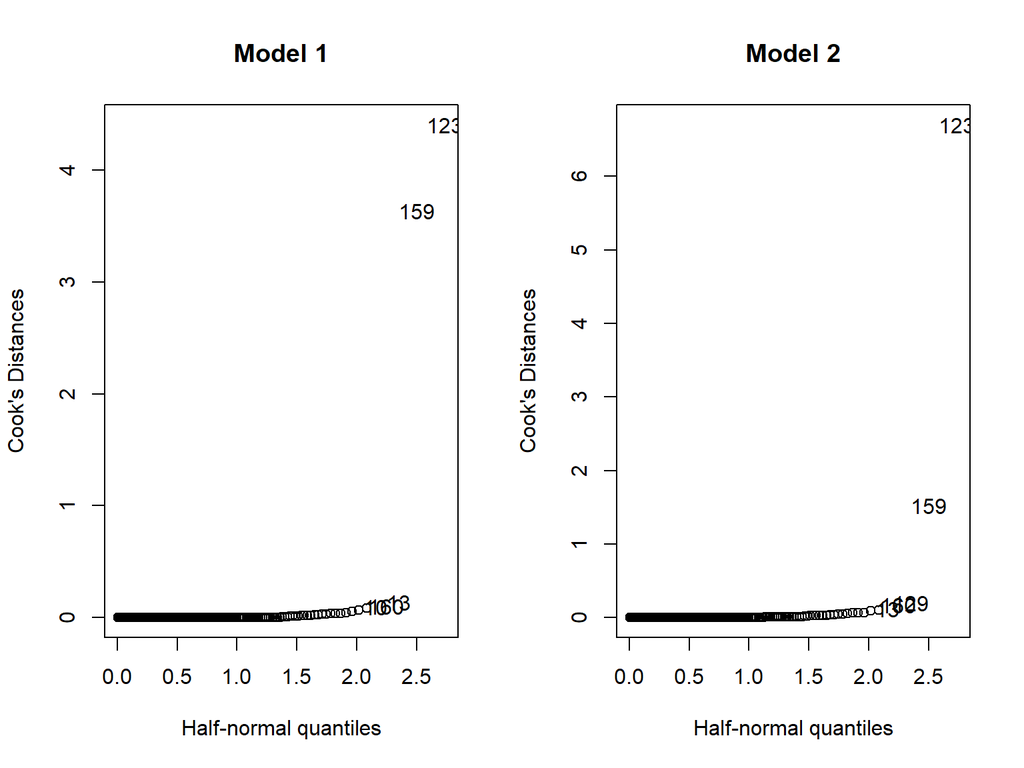

```r
# Influential observations
par(mfrow = c(1, 2))
halfnorm(cooks.distance(rq2.lm), 5, ylab = "Cook's Distances", main = "Model 1")
halfnorm(cooks.distance(rq2.lm.2), 5, ylab = "Cook's Distances", main = "Model 2")
```

Key outliers: observations **159** and **123**.

# 6 Research Question 3: Relationship Between MOID and Orbital Period

> **RQ3:** Is there any relationship between the two response variables, MOID and P? Is there a way to predict the likelihood and/or frequency of a near-Earth comet sighting?

## 6.1 Simple Linear Model: MOID ~ P

```r
rq3.lm <- lm(MOID..AU. ~ P..yr., data = sub.orbit)
summary(rq3.lm)
```

```
##
## Call:
## lm(formula = MOID..AU. ~ P..yr., data = sub.orbit)
##
## Residuals:
##      Min       1Q   Median       3Q      Max
## -0.26054 -0.06702 -0.06654  0.04830  0.40162
##
## Coefficients:
##              Estimate Std. Error t value Pr(>|t|)
## (Intercept) 0.1010874  0.0103129   9.802  < 2e-16 ***
## P..yr.      0.0012031  0.0003139   3.832 0.000183 ***
## ---
## Signif. codes:  0 '***' 0.001 '**' 0.01 '*' 0.05 '.' 0.1 ' ' 1
##
## Residual standard error: 0.115 on 158 degrees of freedom
## Multiple R-squared:  0.08504,    Adjusted R-squared:  0.07925
## F-statistic: 14.69 on 1 and 158 DF,  p-value: 0.000183
```

There is a **highly significant** relationship between MOID and P, though the coefficient is small (0.0012).

```r
cat("Correlation between MOID and P:", cor(sub.orbit$MOID..AU., sub.orbit$P..yr.), "\n")
```

```
## Correlation between MOID and P: 0.2916171
```

## 6.2 Extended Model: MOID ~ P + Q + e

```r
rq3.lm.2 <- lm(MOID..AU. ~ P..yr. + Q..AU. + e, data = sub.orbit)
summary(rq3.lm.2)
```

```
##
## Call:
## lm(formula = MOID..AU. ~ P..yr. + Q..AU. + e, data = sub.orbit)
##
## Residuals:
##      Min       1Q   Median       3Q      Max
## -0.23988 -0.05264 -0.04987  0.04952  0.36029
##
## Coefficients:
##              Estimate Std. Error t value Pr(>|t|)
## (Intercept)  0.046988   0.072615   0.647    0.519
## P..yr.      -0.010369   0.002213  -4.686 6.03e-06 ***
## Q..AU.       0.032008   0.006358   5.034 1.31e-06 ***
## e           -0.093314   0.116949  -0.798    0.426
## ---
## Signif. codes:  0 '***' 0.001 '**' 0.01 '*' 0.05 '.' 0.1 ' ' 1
##
## Residual standard error: 0.1053 on 156 degrees of freedom
## Multiple R-squared:  0.2425, Adjusted R-squared:  0.2279
## F-statistic: 16.65 on 3 and 156 DF,  p-value: 1.967e-09
```

## 6.3 Logistic Regression: Predicting Near-Earth Classification

A comet is classified as “near-Earth” if MOID < 0.05 AU.

```r
sub.orbit$Near <- ifelse(sub.orbit$MOID..AU. < 0.05, 1, 0)

cat("Near-Earth comets:", sum(sub.orbit$Near), "\n")
```

```
## Near-Earth comets: 82
```

```r
cat("Non-near-Earth comets:", sum(sub.orbit$Near == 0), "\n")
```

```
## Non-near-Earth comets: 78
```

```r
rq3.logistic <- glm(
  Near ~ P..yr. + q..AU. + Q..AU. + e + i..deg. + w..deg. + Node..deg.,
  family = binomial,
  data = sub.orbit
)

summary(rq3.logistic)
```

```
##
## Call:
## glm(formula = Near ~ P..yr. + q..AU. + Q..AU. + e + i..deg. +
##     w..deg. + Node..deg., family = binomial, data = sub.orbit)
##
## Coefficients:
##               Estimate Std. Error z value Pr(>|z|)
## (Intercept)  19.290569   7.052529   2.735 0.006233 **
## P..yr.        0.064146   0.103051   0.622 0.533636
## q..AU.       -5.211726   2.296050  -2.270 0.023216 *
## Q..AU.       -0.117660   0.339334  -0.347 0.728789
## e           -19.104004   8.152386  -2.343 0.019111 *
## i..deg.       0.005237   0.014249   0.368 0.713194
## w..deg.       0.003412   0.002340   1.458 0.144738
## Node..deg.   -0.008193   0.002360  -3.472 0.000516 ***
## ---
## Signif. codes:  0 '***' 0.001 '**' 0.01 '*' 0.05 '.' 0.1 ' ' 1
##
## (Dispersion parameter for binomial family taken to be 1)
##
##     Null deviance: 221.71  on 159  degrees of freedom
## Residual deviance: 163.06  on 152  degrees of freedom
## AIC: 179.06
##
## Number of Fisher Scoring iterations: 6
```

Only **q**, **e**, and **Node.deg** are significant predictors of near-Earth classification.

## 6.4 Model Diagnostics (RQ3)

```r
# Normality
cat("Simple model:\n"); shapiro.test(resid(rq3.lm))
```

```
## Simple model:
```

```
##
##  Shapiro-Wilk normality test
##
## data:  resid(rq3.lm)
## W = 0.80352, p-value = 2.168e-13
```

```r
cat("\nExtended model:\n"); shapiro.test(resid(rq3.lm.2))
```

```
##
## Extended model:
```

```
##
##  Shapiro-Wilk normality test
##
## data:  resid(rq3.lm.2)
## W = 0.8622, p-value = 6.07e-11
```

```r
cat("\nLogistic model:\n"); shapiro.test(resid(rq3.logistic))
```

```
##
## Logistic model:
```

```
##
##  Shapiro-Wilk normality test
##
## data:  resid(rq3.logistic)
## W = 0.92315, p-value = 1.617e-07
```

None of the models’ residuals are normally distributed.

```r
# Multicollinearity
cat("Extended model VIF:\n"); vif(rq3.lm.2)
```

```
## Extended model VIF:
```

```
##    P..yr.    Q..AU.         e
## 59.253591 67.868166  2.406026
```

```r
cat("\nLogistic model VIF:\n"); vif(rq3.logistic)
```

```
##
## Logistic model VIF:
```

```
##      P..yr.      q..AU.      Q..AU.           e     i..deg.     w..deg.
## 1423.947513   64.635155 2142.250766  129.568977   37.291053    6.709618
##  Node..deg.
##    8.408365
```

P and Q have high VIF values in both models, indicating significant **multicollinearity**.

```r
# Heteroskedasticity
cat("Simple model:\n"); ncvTest(rq3.lm)
```

```
## Simple model:
```

```
## Non-constant Variance Score Test
## Variance formula: ~ fitted.values
## Chisquare = 10.36427, Df = 1, p = 0.0012848
```

```r
cat("\nExtended model:\n"); ncvTest(rq3.lm.2)
```

```
##
## Extended model:
```

```
## Non-constant Variance Score Test
## Variance formula: ~ fitted.values
## Chisquare = 29.00228, Df = 1, p = 7.2293e-08
```

```r
cat("\nLogistic model (Breusch-Pagan):\n"); bptest(rq3.logistic)
```

```
##
## Logistic model (Breusch-Pagan):
```

```
##
##  studentized Breusch-Pagan test
##
## data:  rq3.logistic
## BP = 17.308, df = 7, p-value = 0.01551
```

All three models exhibit **heteroskedasticity**.

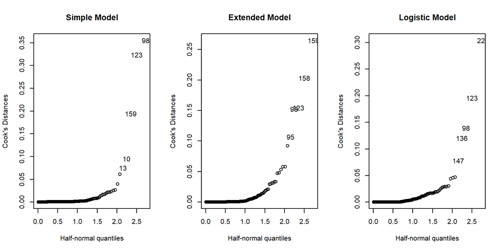

```r
# Influential observations
par(mfrow = c(1, 3))
halfnorm(cooks.distance(rq3.lm), 5, ylab = "Cook's Distances", main = "Simple Model")
halfnorm(cooks.distance(rq3.lm.2), 5, ylab = "Cook's Distances", main = "Extended Model")
halfnorm(cooks.distance(rq3.logistic), 5, ylab = "Cook's Distances", main = "Logistic Model")
```

Consistent outliers across models: observations **123** and **98**.